# Analyse Pumpenprüfstandsdaten (ML-Workflow)

```python
from enum import Enum
import ipywidgets as widgets
from pandas import read_csv
import pandas as pd
import asammdf
from IPython.display import display
import os
import numpy as np
import time
import pathlib as pl
```

```python
# Setting up the global variables

PATH_RAW_DATA = "../Messdaten"
PATH_FEATURE_DATA = "./data/"
PATH_EXPLORATION_DATA = "./exploration/"
PATH_MODEL = "./models/"
DATA_SOURCE_KIDAQ = ["TEST_NAME", "TEST_TYPE", "RPM", "FLOW_RATE", "P1", "P2"]
RAW_DATA_TYPE = ["KIDAQ", "VIB"]

DATA_SOURCE_VID = [
    "TEST_NAME",
    "TEST_TYPE",
    "RPM",
    "FLOW_RATE",
    "S1",
    "S2",
    "S3",
    "S4",
    "S5",
    "S6",
    "S7",
    "S8",
]
FEATURE = [
    "STD",
    "RANGE",
    "IQR",
    "MEAN_MEDIAN",
    "FFT",
]
OPERATING_POINT_FREQ = [725, 1450, 2175, 2900]
OPERATING_POINT_FLOW_RATE = [0, 25, 50, 75, 100]

PREPROCESSING_WINDOW_SIZE_MS_DEFAULT = 1000
PREPROCESSING_WINDOW_SIZE_MS_MIN = 100
PREPROCESSING_WINDOW_SIZE_MS_MAX = 10000

PREPROCESSING_FREQUENCY_BAND_COUNT_DEFAULT = 10
PREPROCESSING_FREQUENCY_BAND_COUNT_MIN = 10
PREPROCESSING_FREQUENCY_BAND_COUNT_MAX = 100

DEFAULT_RAW_DATA_TYPE = RAW_DATA_TYPE[1]
DEFAULT_RAW_DATA = DATA_SOURCE_KIDAQ
DEFAULT_SAMPLE_RATE = 10000

DEFAULT_CLASS_LABEL = "TEST_TYPE"
# 2021-04-28 - Gut 1, 2021-05-19 - Kavitation 1, 2021-05-26 - Fehlausrichtung 1, 2021-07-10 - Laufradschaden 1
TEST_TYPES = ["Gut", "Kavitation", "Fehlausrichtung", "Laufradschaden"]
TEST_TYPE_REGEX = r"\b(?:" + "|".join(TEST_TYPES) + r")\b"

# ..\Messdaten\Setup-I\2021-04-28 - Gut 1\KiDAQ\1450rpm\1450rpm@100%.mf4
TEST_NAME_REGEX = r"\d{4}-\d{2}-\d{2} - [\w\s]+"

KIDAQ_FILE_SEARCH_PATTERN = "**/*.mf4"  # 725rpm@0%.mf4
KIDAQ_FILE_RPM_REGEX = r"(\d+)rpm"
KIDAQ_FILE_FLOW_RATE_REGEX = r"(\d+)%"


KIDAQ_DEFAULT_FEATURES = [
    "test_name",
    "test_type",
    "flow_rate",
    "rpm",
    "p1_std",
    "p2_std",
    "p1_range",
    "p2_range",
    "p1_iqr",
    "p2_iqr",
    "p1_mean_median",
    "p2_mean_median",
]

VIB_DEFAULT_FEATURES = [
    "test_name",
    "test_type",
    "flow_rate",
    "rpm",
    "s1_std",
    "s2_std",
    "s3_std",
    "s4_std",
    "s5_std",
    "s6_std",
    "s7_std",
    "s8_std",
    "s1_range",
    "s2_range",
    "s3_range",
    "s4_range",
    "s5_range",
    "s6_range",
    "s7_range",
    "s8_range",
    "s1_iqr",
    "s2_iqr",
    "s3_iqr",
    "s4_iqr",
    "s5_iqr",
    "s6_iqr",
    "s7_iqr",
    "s8_iqr",
    "s1_mean_median",
    "s2_mean_median",
    "s3_mean_median",
    "s4_mean_median",
    "s5_mean_median",
    "s6_mean_median",
    "s7_mean_median",
    "s8_mean_median"
]

# 2900_25_1.mf4

KIDAQ_FILE_FIX_REGEX = r"(\d+)_(\d+)_(\d+).mf4"


VIB_FILE_SEARCH_PATTERN = (
    "**/VIB*.csv"  # 725rpm\0%\1\VIB1 2021-05-03 10-58-02.453.519.300.csv
)
VIB_FILE_SENSOR_REGEX = r"VIB(\d+)"
VIB_FILE_RPM_REGEX = r"(\d+)rpm"
VIB_FILE_FLOW_RATE_REGEX = r"(\d+)%"
VIB_SENSOR_COUNT = 8
```

## 3. Preprocessing

Aufgeteilt nach KIDAQ und VIB

- Auswahl der Fenstergröße in Millisekunden
- Auswahl des Setups
- Frequenzanalyse (Fourier-Transformation)
  - Abtastrate
  - Maximalfrequenz
  - Feature Resampling
  - Fenstergröße der Aggregationen nach Frequenzbereichen

```python
# Preprocessing parameters

windowSizeSlider = widgets.IntSlider(
    value=PREPROCESSING_WINDOW_SIZE_MS_DEFAULT,
    min=PREPROCESSING_WINDOW_SIZE_MS_MIN,
    max=PREPROCESSING_WINDOW_SIZE_MS_MAX,
    step=100,
    description='Window size:'
)
display(windowSizeSlider)

dataSourceDropdown = widgets.Dropdown(
    options=RAW_DATA_TYPE,
    description='Data source:'
)

display(dataSourceDropdown)

setups = list(filter(lambda x: os.path.isdir(os.path.join(PATH_RAW_DATA, x)), os.listdir(PATH_RAW_DATA)))

setupSelectionDropdown = widgets.Dropdown(
    options=setups,
    description='Setup:'
)

display(setupSelectionDropdown)



sampleRateInput = widgets.IntText(
    value=DEFAULT_SAMPLE_RATE,
    description='Sample rate:',
)



maxFrequencyInput = widgets.IntText(
    value=DEFAULT_SAMPLE_RATE / 10,
    description='Max. frequency:',
)

frequencyResampleInput = widgets.IntText(
    value=DEFAULT_SAMPLE_RATE / 100,
    description='Resample count:',
)

frequencyBandCountSlider = widgets.IntSlider(
    value=PREPROCESSING_FREQUENCY_BAND_COUNT_DEFAULT,
    min=PREPROCESSING_FREQUENCY_BAND_COUNT_MIN,
    max=PREPROCESSING_FREQUENCY_BAND_COUNT_MAX,
    step=10,
    description='Freq. bands:'
)

displayed = False
def showFrequencyAnalysisInput():
    global displayed
    if not displayed:
        display(sampleRateInput)
        display(maxFrequencyInput)
        display(frequencyResampleInput)
        display(frequencyBandCountSlider)
        displayed = True

selectFrequencyAnalysis = widgets.Checkbox(
    value=False,
    description='Frequency analysis:'
)

selectFrequencyAnalysis.observe(lambda x: showFrequencyAnalysisInput(), names='value')

display(selectFrequencyAnalysis)
```

```
IntSlider(value=1000, description='Window size:', max=10000, min=100, step=100)
```

```
Dropdown(description='Data source:', options=('KIDAQ', 'VIB'), value='KIDAQ')
```

```
Dropdown(description='Setup:', options=('Setup-I', 'Setup-II'), value='Setup-I')
```

```
Checkbox(value=False, description='Frequency analysis:')
```

```
IntText(value=10000, description='Sample rate:')
```

```
IntText(value=1000, description='Max. frequency:')
```

```
IntText(value=100, description='Resample count:')
```

```
IntSlider(value=10, description='Freq. bands:', min=10, step=10)
```

```python
# FFT helper functions

from matplotlib import pyplot
import numpy as np
import pandas as pd
from scipy import stats
from scipy.stats import skew, kurtosis
from scipy.signal import find_peaks


def compute_top_n_amplitudes(fft_values, n):
    sorted_indices = np.argsort(fft_values)  # Sortiere die Amplituden
    top_indices = sorted_indices[-n:]  # Wähle die Top-N-Amplituden aus
    top_amplitudes = fft_values[top_indices]
    return top_amplitudes[::-1]


def compute_top_n_frequencies(fft_values, n):
    sorted_indices = np.argsort(fft_values)  # Sortiere die Amplituden
    top_frequencies = sorted_indices[-n:]  # Wähle die Top-N-Amplituden aus
    return top_frequencies[::-1]


def compute_energy_in_bands(fft_values, bands):
    energy = []
    for band in bands:
        band_values = fft_values[band[0] : band[1]]  # Frequenzbereich für das Band
        band_energy = np.sum(np.abs(band_values) ** 2)  # Berechne die Energie im Band
        energy.append(band_energy)
    return energy


def compute_spectral_features(fft_values):
    spectral_skewness = skew(np.abs(fft_values))
    spectral_kurt = kurtosis(np.abs(fft_values))
    amplitudes = np.abs(fft_values)  # Berechnung der Amplituden
    geometric_mean = np.exp(
        np.mean(np.log(amplitudes[amplitudes != 0]))
    )  # Berechnung des geometrischen Mittelwerts

    spectral_flatness = geometric_mean / (
        np.mean(amplitudes) + np.finfo(float).eps
    )  # Berechnung des spektralen Flachheitsmaßes
    return spectral_skewness, spectral_kurt, spectral_flatness


def compute_frequency_bands_mean(fft_values, bands):
    band_features = []
    for band in bands:
        band_values = fft_values[band[0] : band[1]]
        band_feature = np.mean(
            np.abs(band_values)
        )  # Hier: Durchschnittliche Amplitude im Band
        band_features.append(band_feature)
    return band_features


def compute_harmonic_dominance(fft_values):
    fundamental_amplitude = np.abs(fft_values[0])  # Amplitude der Grundfrequenz
    harmonic_amplitudes = np.abs(
        fft_values[1:]
    )  # Amplituden der harmonischen Frequenzen
    total_harmonic_amplitude = np.sum(
        harmonic_amplitudes
    )  # Summe der harmonischen Amplituden
    harmonic_dominance = total_harmonic_amplitude / (
        fundamental_amplitude + total_harmonic_amplitude
    )
    return harmonic_dominance


def compute_periodicity(fft_values, n):
    fundamental_amplitude = np.abs(fft_values[0])  # Amplitude der Grundfrequenz
    residual_amplitudes = np.abs(
        fft_values[1:]
    )  # Amplituden der nicht-grundfrequenten Komponenten
    significant_residuals = residual_amplitudes[-n:]  # Filtere signifikante Komponenten
    periodicity = np.sum(significant_residuals) / fundamental_amplitude
    return periodicity


def count_harmonic_peaks(fft_values, relative_peak_threshold):
    threshold = relative_peak_threshold * np.max(
        np.abs(fft_values)
    )  # Schwellwert für die Peak-Erkennung
    peaks, _ = find_peaks(
        np.abs(fft_values), height=threshold
    )  # Finde Peaks im Amplitudenspektrum
    harmonic_peak_count = (
        len(peaks) - 1
    )  # Zähle die Anzahl der Peaks (ohne die Grundfrequenz)
    return harmonic_peak_count


def extractBandFeatures(
    fft,
    fftFreq,
    maxFrequency,
    resolution,
    frequencyBandCount,
    relativePeakThreshold=0.25,
):
    fftDf = pd.DataFrame(np.abs(fft), index=fftFreq)
    fftDf = fftDf.loc[(fftDf.index >= 0) & (fftDf.index <= maxFrequency)]

    flattenedFFT = fftDf.values.flatten()
    bands = [
        [
            int(i * maxFrequency * resolution / frequencyBandCount),
            (int((i + 1) * maxFrequency * resolution / frequencyBandCount) - 1),
        ]
        for i in range(frequencyBandCount)
    ]
    top_n_amplitudes = compute_top_n_amplitudes(flattenedFFT, frequencyBandCount)
    top_n_frequencies = compute_top_n_frequencies(flattenedFFT, frequencyBandCount)
    band_energy = compute_energy_in_bands(flattenedFFT, bands)
    spectral_skewness, spectral_kurt, spectral_flatness = compute_spectral_features(
        flattenedFFT
    )
    frequency_bands = compute_frequency_bands_mean(flattenedFFT, bands)
    harmonic_dominance = compute_harmonic_dominance(flattenedFFT)
    periodicity = compute_periodicity(flattenedFFT, frequencyBandCount)
    harmonic_peak_count = count_harmonic_peaks(flattenedFFT, relativePeakThreshold)
    data = np.concatenate(
        (
            top_n_amplitudes,
            top_n_frequencies / resolution,
            band_energy,
            frequency_bands,
            [
                spectral_skewness,
                spectral_kurt,
                spectral_flatness,
                harmonic_dominance,
                periodicity,
                harmonic_peak_count,
            ],
        )
    )

    feature_names = np.concatenate(
        (
            [f"amplitude_{i+1}_highest_energy" for i in range(frequencyBandCount)],
            [f"amplitude_{i+1}_highest_freq" for i in range(frequencyBandCount)],
            [
                f"band_{band[0]/resolution}_{band[1]/resolution}_energy"
                for band in bands
            ],
            [
                f"band_{band[0]/resolution}_{band[1]/resolution}_energy_mean"
                for band in bands
            ],
            [
                "spectral_skewness",
                "spectral_kurt",
                "spectral_flatness",
                "harmonic_dominance",
                "periodicity",
                "harmonic_peak_count",
            ],
        )
    )

    df = pd.DataFrame(data)
    df.index = feature_names

    return df


def extractFlattenedFeatureNames(dataFrame):
    featureNames = []
    for row in dataFrame.index:
        for col in dataFrame.columns:
            featureNames.append("_".join([row, col]))
    return featureNames


def extractAggregationFeatures(fft, fftFreq, maxFrequency, aggregationResampleCount):
    fftDf = pd.DataFrame(np.abs(fft), index=fftFreq)
    fftDf = fftDf.loc[(fftDf.index >= 0) & (fftDf.index <= maxFrequency)]

    windowSize = int(maxFrequency / aggregationResampleCount)
    fftMax = fftDf.max()

    windowLabels = [
        f"{windowSize * i}_{windowSize * (i+1)}"
        for i in range(aggregationResampleCount)
    ]
    fftDf.index = pd.cut(
        fftDf.index, bins=aggregationResampleCount, labels=windowLabels
    )
    fftWindows = fftDf.groupby(fftDf.index)
    fftDf = pd.concat(
        [
            fftWindows.std().fillna(0),
            (fftWindows.max() - fftWindows.min()).fillna(0),
            fftWindows.aggregate(lambda sample: stats.iqr(sample.to_numpy())).fillna(0),
            (fftWindows.mean() - fftWindows.median()).fillna(0),
            (fftWindows.max() / fftMax).fillna(0),
        ],
        axis=1,
    )
    fftDf.columns = ["std", "range", "iqr", "mean_median", "relative_max"]
    fftDf.index.name = "freq_window"

    return pd.DataFrame(
        fftDf.to_numpy().flatten(), index=extractFlattenedFeatureNames(fftDf)
    )


def fftFeatureExtraction(
    samples, sampleRate, maxFrequency, aggregationResampleCount, frequencyBandCount
):
    resolution = len(samples) / sampleRate
    fft = np.fft.fft(samples)
    fftFreq = np.fft.fftfreq(len(samples), 1 / sampleRate)
    aggregationFeatures = extractAggregationFeatures(
        fft, fftFreq, maxFrequency, aggregationResampleCount
    )
    bandFeatures = extractBandFeatures(
        fft, fftFreq, maxFrequency, resolution, frequencyBandCount
    )
    return pd.concat([aggregationFeatures, bandFeatures])
```

```python
# Start the preprocessing
import re
from asammdf import MDF
from tqdm.notebook import tqdm


windowSize = windowSizeSlider.value
setup = setupSelectionDropdown.value
rawDataType = dataSourceDropdown.value
frequencyAnalysis = selectFrequencyAnalysis.value
sampleRate = sampleRateInput.value
maxFrequency = maxFrequencyInput.value
resampleCount = frequencyResampleInput.value
frequencyBandCount = frequencyBandCountSlider.value

fileName = f"{setup}_{rawDataType}_{windowSize}.csv"

if frequencyAnalysis:
    fileName = f"{setup}_{rawDataType}_{windowSize}ws_{sampleRate}sr_{maxFrequency}mf_{resampleCount}rc_{frequencyBandCount}fbc.csv"


outputFile = open(
    os.path.join(PATH_FEATURE_DATA, fileName),
    "w",
)

headerWritten = False
match rawDataType:
    case "KIDAQ":
        columns = KIDAQ_DEFAULT_FEATURES
        sensorInColumns = []

        kidaqFiles = list(
            pl.Path(os.path.join(PATH_RAW_DATA, setup)).glob(KIDAQ_FILE_SEARCH_PATTERN)
        )
        for file in tqdm(kidaqFiles):
            testName = re.search(TEST_NAME_REGEX, str(file)).group(0)
            testType = re.search(TEST_TYPE_REGEX, str(file)).group(0)
            secondFormat = re.search(KIDAQ_FILE_FIX_REGEX, file.name)
            if secondFormat:
                rpm = secondFormat.group(1)
                flowRate = secondFormat.group(2)
            else:
                rpm = re.search(KIDAQ_FILE_RPM_REGEX, file.name).group(1)
                flowRate = re.search(KIDAQ_FILE_FLOW_RATE_REGEX, file.name).group(1)

            mdf = MDF(file)
            df = mdf.filter(["p1", "p2"]).to_dataframe()
            df.index = pd.to_timedelta(df.index, unit="s")
            resampled = df.resample(str(windowSize) + "ms")

            median = resampled.median().to_numpy()
            mean = resampled.mean().to_numpy()
            max_val = resampled.max().to_numpy()
            min_val = resampled.min().to_numpy()
            std = resampled.std().to_numpy()
            range_val = max_val - min_val
            iqr = resampled.aggregate(
                lambda sample: stats.iqr(sample.to_numpy())
            ).to_numpy()

            result = np.concatenate(
                (
                    np.repeat(
                        [[testName, testType, flowRate, rpm]],
                        len(std),
                        axis=0,
                    ),
                    std,
                    range_val,
                    iqr,
                    median - mean,
                ),
                axis=1,
            )
            if frequencyAnalysis:
                fftAnalysisWindows = []
                for samples in resampled:
                    fftAnalysis = []
                    for sensor in samples[1]:
                        frequencyFeatures = fftFeatureExtraction(
                            samples[1][sensor],
                            sampleRate,
                            maxFrequency,
                            resampleCount,
                            frequencyBandCount,
                        )
                        if not sensor in sensorInColumns:
                            columns = np.concatenate(
                                (columns, sensor + "_" + frequencyFeatures.index)
                            )
                            sensorInColumns.append(sensor)
                        fftAnalysis.append(frequencyFeatures.to_numpy().flatten())
                    fftAnalysisWindows.append(np.concatenate(fftAnalysis, axis=0))
                result = np.concatenate(
                    (result, fftAnalysisWindows),
                    axis=1,
                )

            if not headerWritten:
                outputFile.write(";".join(columns) + "\n")
                headerWritten = True
            for row in result:
                outputFile.write(";".join(row) + "\n")

    case "VIB":
        columns = VIB_DEFAULT_FEATURES
        sensorInColumns = []

        vibFiles = list(
            pl.Path(os.path.join(PATH_RAW_DATA, setup)).glob(VIB_FILE_SEARCH_PATTERN)
        )

        currentTestFiles = []
        currentTestSzenario = ""
        for file in tqdm(vibFiles):
            testSzenario = os.path.dirname(file)

            if testSzenario != currentTestSzenario and len(currentTestFiles) > 0:
                sensorData = []
                for testFile in currentTestFiles:
                    testType = re.search(TEST_TYPE_REGEX, str(testFile)).group(0)
                    testName = re.search(TEST_NAME_REGEX, str(file)).group(0)

                    rpm = re.search(VIB_FILE_RPM_REGEX, str(testFile)).group(1)
                    flowRate = re.search(VIB_FILE_FLOW_RATE_REGEX, str(testFile)).group(
                        1
                    )
                    sensor = re.search(VIB_FILE_SENSOR_REGEX, testFile.name).group(1)

                    dataFrame = pd.read_csv(
                        testFile,
                        skiprows=2,
                        encoding="ISO-8859-1",
                        sep=";",
                        index_col=0,
                    )
                    dataFrame.index = pd.to_datetime(dataFrame.index, unit="ns")

                    while len(sensorData) < VIB_SENSOR_COUNT:
                        placeholder = pd.DataFrame(
                            0, index=dataFrame.index, columns=dataFrame.columns
                        )
                        placeholder.rename(
                            columns={"Value": "VIB" + str(len(sensorData) + 1)},
                            inplace=True,
                        )
                        sensorData.append(placeholder)

                    dataFrame.rename(
                        columns={"Value": "VIB" + str(sensor)}, inplace=True
                    )

                    sensorData[int(sensor) - 1] = dataFrame

                currentTestFiles = []

                mergedSensorData = sensorData[0]
                for i in range(1, len(sensorData)):
                    mergedSensorData = pd.merge_asof(
                        mergedSensorData,
                        sensorData[i],
                        left_index=True,
                        right_index=True,
                        tolerance=pd.Timedelta(str(windowSize // 100) + "ms"),
                    )

                resampled = mergedSensorData.resample(
                    str(windowSize) + "ms", origin="end"
                )

                median = resampled.median().to_numpy()
                mean = resampled.mean().to_numpy()
                max_val = resampled.max().to_numpy()
                min_val = resampled.min().to_numpy()
                std = resampled.std().to_numpy()

                range_val = max_val - min_val
                iqr = resampled.aggregate(
                    lambda sample: stats.iqr(sample.to_numpy())
                ).to_numpy()

                result = np.concatenate(
                    (
                        np.repeat(
                            [[testName, testType, flowRate, rpm]],
                            len(std),
                            axis=0,
                        ),
                        std,
                        range_val,
                        iqr,
                        median - mean,
                    ),
                    axis=1,
                )
                if frequencyAnalysis:
                    fftAnalysisWindows = []
                    for samples in resampled:
                        fftAnalysis = []
                        if samples[1].shape[0] >= (
                            maxFrequency * (windowSize / 1000) * 2
                        ):
                            for sensor in samples[1]:
                                sensorSamples = samples[1][sensor]
                                frequencyFeatures = fftFeatureExtraction(
                                    sensorSamples,
                                    sampleRate,
                                    maxFrequency,
                                    resampleCount,
                                    frequencyBandCount,
                                )
                                if not sensor in sensorInColumns:
                                    columns = np.concatenate(
                                        (
                                            columns,
                                            sensor + "_" + frequencyFeatures.index,
                                        )
                                    )
                                    sensorInColumns.append(sensor)
                                fftAnalysis.append(
                                    frequencyFeatures.to_numpy().flatten()
                                )
                        else:
                            fftAnalysis = [
                                np.array([0])
                                for i in range(
                                    samples[1].shape[1]
                                    * (frequencyBandCount * 4 + 6 + resampleCount * 5)
                                )
                            ]
                        fftAnalysisWindows.append(np.concatenate(fftAnalysis, axis=0))

                    result = np.concatenate(
                        (result, np.array(fftAnalysisWindows)),
                        axis=1,
                    )

                result = result[~np.any(result == "nan", axis=1)]

                if not headerWritten:
                    outputFile.write(";".join(columns) + "\n")
                    headerWritten = True
                for row in result:
                    outputFile.write(";".join(row) + "\n")

            currentTestSzenario = testSzenario
            currentTestFiles.append(file)
```

### 3.1 Vorbereitung der Tainings- und Testdaten

- Vorverarbeitete Daten auswählen
- Features wählen
- Nach Spaltenwert filtern (z.B. Betriebspunkte oder Szenarien)
- neuen Namen eingeben und speichern

```python
# SELECT PREPROCESSED DATA
featureDataDir = list(
    filter(
        lambda x: os.path.isfile(os.path.join(PATH_FEATURE_DATA, x)),
        os.listdir(PATH_FEATURE_DATA),
    )
)

preprocessedData = pd.DataFrame()
preprocessedFileDropdown = widgets.Dropdown(description="preprocessed data")
preprocessedFileDropdown.options = featureDataDir
display(preprocessedFileDropdown)

# SELECT FEATURES
featureSelection = widgets.SelectMultiple(description="features")
display(featureSelection)

rowSelectorColumn = widgets.Dropdown(description="row selector column")
display(rowSelectorColumn)
rowSelection = widgets.SelectMultiple(description="rows")
display(rowSelection)


def updateDynamicFields():
    global featureSelection
    global rowSelection
    global rowSelectorColumn
    featureSelection.options = list(preprocessedData.columns)
    featureSelection.value = featureSelection.options
    rowSelectorColumn.options = list(preprocessedData.columns)
    rowSelectorColumn.value = rowSelectorColumn.options[0]


def rowSelectorColumnChange(change):
    global rowSelection
    rowSelection.options = list(preprocessedData[change.new].unique())
    rowSelection.value = rowSelection.options


def onPreprocessedFileChange(change):
    global preprocessedData
    preprocessedData = pd.read_csv(os.path.join(PATH_FEATURE_DATA, change.new), sep=";")
    updateDynamicFields()


preprocessedFileDropdown.observe(onPreprocessedFileChange, names="value")
rowSelectorColumn.observe(rowSelectorColumnChange, names="value")

saveName = widgets.Text(description="new name")
display(saveName)
saveButton = widgets.Button(description="save")
display(saveButton)

def onSaveButtonClick(b):
    global preprocessedData
    global featureSelection
    global rowSelection
    global saveName
    global rowSelectorColumn
    global saveButton

    selectedFeatures = featureSelection.value
    selectedRows = rowSelection.value
    rowSelector = rowSelectorColumn.value

    if len(selectedFeatures) > 0 and len(selectedRows) > 0 and len(rowSelector) > 0:
        preprocessedData = preprocessedData[preprocessedData[rowSelector].isin(selectedRows)]
        preprocessedData = preprocessedData.loc[:, selectedFeatures]

        preprocessedData.to_csv(os.path.join(PATH_FEATURE_DATA, saveName.value + ".csv"), sep=";", index=False)
        saveButton.style.button_color = "lightgreen"


saveButton.on_click(onSaveButtonClick)
```

```
Dropdown(description='preprocessed data', options=('kidaq.Setup-I.100s.fft32.csv', 'kidaq.Setup-I.10s.fft10 co…
```

```
SelectMultiple(description='features', options=(), value=())
```

```
Dropdown(description='row selector column', options=(), value=None)
```

```
SelectMultiple(description='rows', options=(), value=())
```

```
Text(value='', description='new name')
```

```
Button(description='save', style=ButtonStyle())
```

## 5. Maschinelles Lernen

In diesem Bereich können, mithilfe drei verschiedener Learner, Modell anhand der generierten Trainings- und Testdaten erzeugt werden.

### 5.1 Trainings- und Testdaten wählen und laden

```python
# SELECT TRAINING AND TEST DATA
featureDataDir = list(filter(lambda x: os.path.isfile(os.path.join(PATH_FEATURE_DATA, x)), os.listdir(PATH_FEATURE_DATA)))

trainFileDropdown = widgets.Dropdown(description="training data")
trainFileDropdown.options = featureDataDir
display(trainFileDropdown)

testFileDropdown = widgets.Dropdown(description="test data")
testFileDropdown.options = featureDataDir
display(testFileDropdown)
```

```
Dropdown(description='training data', options=('kidaq.Setup-I.100s.fft32.csv', 'kidaq.Setup-I.10s.fft10 copy 2…
```

```
Dropdown(description='test data', options=('kidaq.Setup-I.100s.fft32.csv', 'kidaq.Setup-I.10s.fft10 copy 2.csv…
```

```python
# LOAD DATA
csvTrain = read_csv(PATH_FEATURE_DATA + trainFileDropdown.value, delimiter=";")
csvTest = read_csv(PATH_FEATURE_DATA + testFileDropdown.value, delimiter=";")

DATA_INDEX_CLASS = 1
DATA_INDEX_TIME_BASED = 2
DATA_INDEX_FREQ_BASED = 12

trainData = csvTrain.values
testData = csvTest.values


featureNames = csvTrain.columns.values[DATA_INDEX_TIME_BASED:].tolist()
trainX, trainY = trainData[:, DATA_INDEX_TIME_BASED:].astype(np.float32), trainData[:, DATA_INDEX_CLASS:DATA_INDEX_CLASS+1]
testX, testY = testData[:, DATA_INDEX_TIME_BASED:].astype(np.float32), testData[:, DATA_INDEX_CLASS:DATA_INDEX_CLASS+1]
```

### 5.2 Entscheidungsbaum - sklearn (empfohlen)

In diesem Abschnitt wird mit der sklearn-Bibliothek ein Entscheidungsbaummodell trainiert. Dabei können verschiedene Parameter frei gewählt werden, wie die maximale Baumtiefe, die gewünschte Mindestgenauigkeit und die Anzahl der Suchiterationen. Das Programm wird dann versuchen, ausgehend von einer Baumtiefe von eins, einen möglichst einfachen Entscheidungsbaum zu generieren, der die gewünschte Genauigkeit erreicht.

#### 5.2.1 Konfiguration

```python
DT_MAX_DEPTH = 6                           # Maximum depth of the tree
DT_EXPLORATION_TARGET_VAL_ACCURACY = 0.9   # Target accuracy for the decision tree
DT_EXPLORATION_MAX_ITER = 10000            # Maximum number of iterations for the random search
DT_VERBOSE = False                         # Verbose logging for the decision tree
```

#### 5.2.2 Trainieren

```python
# Train DecisionTreeClassifier
from matplotlib import pyplot as plt
from sklearn import tree
from sklearn.tree import DecisionTreeClassifier
from sklearn.metrics import accuracy_score
from sklearn.preprocessing import LabelEncoder
from IPython.display import clear_output
import joblib

labelEncoder = LabelEncoder()
labelEncoder = labelEncoder.fit(np.ravel(trainY))
labelEncodedTrainY = labelEncoder.transform(np.ravel(trainY))
labelEncodedTestY = labelEncoder.transform(np.ravel(testY))


testAccuracy = 0.0
trainAccuracy = 0.0
iterations = 0
depth = 1
while (
    testAccuracy < DT_EXPLORATION_TARGET_VAL_ACCURACY
    or trainAccuracy < DT_EXPLORATION_TARGET_VAL_ACCURACY
) and iterations < DT_EXPLORATION_MAX_ITER:
    # Create decision tree classifier


    dt = DecisionTreeClassifier(max_depth=depth, splitter="random")
    dt.fit(trainX, labelEncodedTrainY)

    testPredictions = dt.predict(testX)
    testAccuracy = accuracy_score(labelEncodedTestY, testPredictions)

    trainPredictions = dt.predict(trainX)
    trainAccuracy = accuracy_score(labelEncodedTrainY, trainPredictions)
    iterations += 1

    if DT_VERBOSE:
        print("Iteration: %d" % iterations)
        print("Depth: %d" % depth)
        print("Train Accuracy: %.2f%%" % (trainAccuracy * 100.0))
        print("Test Accuracy: %.2f%%" % (testAccuracy * 100.0))



    depth = 1 + iterations // (DT_EXPLORATION_MAX_ITER // DT_MAX_DEPTH)


print("Iteration: %d" % iterations)
print("Depth: %d" % depth)
print("Train Accuracy: %.2f%%" % (trainAccuracy * 100.0))
print("Test Accuracy: %.2f%%" % (testAccuracy * 100.0))

modelName = "dtc." + str(round(time.time()))
os.makedirs(PATH_MODEL + modelName)
with open(PATH_MODEL + modelName + "/encoder.pickle", "wb") as f:
    joblib.dump(labelEncoder, f)
joblib.dump(dt, PATH_MODEL + modelName + "/dtc.model")
```

[output not shown]

```
['./models/dtc.1686191702/dtc.model']
```

### 5.3 Tiefes neuronales Netz - tensorflow

Im folgenden Abschnitt wird mit der tensorflow-Bibliothek ein tiefes neuronales Netzwerk trainiert. Dabei können verschiedene Parameter eingestellt werden, wie die gewünschte Mindestgenauigkeit, die Anzahl der Suchiterationen, die minimale und maximale Anzahl an Schichten und Neuronen, die Toleranz für einen vorzeitigen Abbruch einer Iteration, die Ausgabeform, die maximale Anzahl an Epochen, die Batchgröße und die Batch Normalisierung.

Bitte beachte, dass die genaue Syntax und die verfügbaren Optionen von tensorflow abhängen können. Es ist empfehlenswert, die offizielle tensorflow-Dokumentation für detaillierte Informationen zu konsultieren.

#### 5.3.1 Konfiguration

```python
DNN_EXPLORATION_TARGET_VAL_ACCURACY = 0.9  # Target accuracy for the neural network
DNN_EXPLORATION_MAX_ITER = 50              # Maximum number of iterations for the random search
DNN_EXPLORATION_HIDDEN_LAYERS_MIN = 1       # Minimum number of hidden layers
DNN_EXPLORATION_HIDDEN_LAYERS_MAX = 3       # Maximum number of hidden layers
DNN_EXPLORATION_NEURONS_MIN = 8             # Minimum number of neurons per layer
DNN_EXPLORATION_NEURONS_MAX = 32            # Maximum number of neurons per layer


DNN_EARLY_STOPPING_PATIENCE = 50            # Patience for early stopping
DNN_VERBOSE = 0                             # Verbosity level for the neural network
DNN_EPOCHS = 2000                           # Maximum number of epochs for the neural network
DNN_BATCH_SIZE = 128                        # Batch size for the neural network
DNN_BATCH_NORMALIZATION = True              # Batch normalization for the neural network
```

#### 5.3.2 Trainieren

```python
# Train Neural Network
import json
import random
import joblib
from sklearn.preprocessing import OneHotEncoder
from tensorflow.keras import Sequential
from tensorflow.keras.layers import Dense, InputLayer, BatchNormalization
from tensorflow.keras.callbacks import EarlyStopping

onehotencoder = OneHotEncoder()
onehotencoder = onehotencoder.fit(trainY)
onehotEncodedTrainY = onehotencoder.transform(trainY).toarray()
onehotEncodedTestY = onehotencoder.transform(testY).toarray()

explorationResults = []


numberOfFeatures = trainX.shape[1]
categorieCount = len(onehotEncodedTrainY[0])

testAccuracy = 0.0
trainAccuracy = 0.0
model = Sequential()
interation = 0
while (
    testAccuracy < DNN_EXPLORATION_TARGET_VAL_ACCURACY
    or trainAccuracy < DNN_EXPLORATION_TARGET_VAL_ACCURACY
) and interation < DNN_EXPLORATION_MAX_ITER:
    model = Sequential()
    model.add(InputLayer(input_shape=(numberOfFeatures,)))
    if DNN_BATCH_NORMALIZATION:
        model.add(BatchNormalization())
    denseCount = random.randint(
        DNN_EXPLORATION_HIDDEN_LAYERS_MIN, DNN_EXPLORATION_HIDDEN_LAYERS_MAX
    )
    denseNeurons = []
    for i in range(0, denseCount):
        neuronCount = random.randint(
            DNN_EXPLORATION_NEURONS_MIN, DNN_EXPLORATION_NEURONS_MAX
        )
        denseNeurons.append(neuronCount)
        model.add(Dense(neuronCount, activation="tanh"))
        if DNN_BATCH_NORMALIZATION:
            model.add(BatchNormalization())
    model.add(Dense(categorieCount, activation="sigmoid"))
    model.compile(
        optimizer="adam", loss="categorical_crossentropy", metrics=["accuracy"]
    )
    model.fit(
        trainX,
        onehotEncodedTrainY,
        epochs=DNN_EPOCHS,
        batch_size=DNN_BATCH_SIZE,
        verbose=DNN_VERBOSE,
        validation_data=(testX, onehotEncodedTestY),
        callbacks=[
            EarlyStopping(
                monitor="val_loss",
                patience=DNN_EARLY_STOPPING_PATIENCE,
                restore_best_weights=True,
            )
        ],
    )

    trainLoss, trainAccuracy = model.evaluate(trainX, onehotEncodedTrainY, verbose=DNN_VERBOSE)
    testLoss, testAccuracy = model.evaluate(testX, onehotEncodedTestY, verbose=DNN_VERBOSE)

    explorationResults.append(
        {
            "dense_count": denseCount,
            "dense_neurons": denseNeurons,
            "train_loss": trainLoss,
            "train_acc": trainAccuracy,
            "test_loss": testLoss,
            "test_acc": testAccuracy,
        }
    )
    interation += 1

modelName = "dnn." + str(round(time.time()))

model.save(PATH_MODEL + modelName)
print("Iteration: %d" % interation)
print("Train Accuracy: %.2f%%" % (trainAccuracy * 100.0))
print("Test Accuracy: %.2f%%" % (testAccuracy * 100.0))

with open(PATH_MODEL + modelName + "/encoder.pickle", "wb") as f:
    joblib.dump(onehotencoder, f)

with open(PATH_EXPLORATION_DATA + modelName + ".exploration_results.json", "w") as f:
    json.dump(explorationResults, f, indent=4)
```

```
WARNING:absl:Found untraced functions such as _update_step_xla while saving (showing 1 of 1). These functions will not be directly callable after loading.
```

```
INFO:tensorflow:Assets written to: ./models/dnn.1686192246\assets
```

```
INFO:tensorflow:Assets written to: ./models/dnn.1686192246\assets
```

```
Iteration: 29
Train Accuracy: 99.18%
Test Accuracy: 96.18%
```

### 5.4 Extremes Gradienten-Boosting - XGBoost

In diesem Abschnitt wird mit der xgboost-Bibliothek ein Modell mithilfe des "Extreme Gradient Boosting" trainiert. Dabei können verschiedene Parameter frei gewählt werden, wie die maximale Anzahl der Bäume, die gewünschte Mindestgenauigkeit und die Anzahl der Suchiterationen.

#### 5.4.1 Konfiguration

```python
DT_MAX_DEPTH = 16                           # Maximum depth of the tree
DT_EXPLORATION_TARGET_VAL_ACCURACY = 0.9    # Target accuracy for the decision tree
DT_EXPLORATION_MAX_ITER = 100               # Maximum number of iterations for the random search
DT_VERBOSE = False                          # Verbose logging for the decision tree
DT_NUM_OF_ESTIMATORS = 10                 # number of estimators (default = None -> number of estimators = number of classes)
```

#### 5.4.2 Trainieren

```python
# Train XGBClassifier
import pandas as pd
from sklearn.preprocessing import LabelEncoder
from sklearn.metrics import accuracy_score
from xgboost import XGBClassifier
import joblib


labelEncoder = LabelEncoder()
labelEncoder = labelEncoder.fit(np.ravel(trainY))
labelEncodedTrainY = labelEncoder.transform(np.ravel(trainY))
labelEncodedTestY = labelEncoder.transform(np.ravel(testY))

testAccuracy = 0.0
trainAccuracy = 0.0
iterations = 0
while (
    testAccuracy < DT_EXPLORATION_TARGET_VAL_ACCURACY
    or trainAccuracy < DT_EXPLORATION_TARGET_VAL_ACCURACY
) and iterations < DT_EXPLORATION_MAX_ITER:
    xgb = XGBClassifier(
        tree_method="hist",
        enable_categorical=True,
        max_depth=DT_MAX_DEPTH,
        n_estimators=labelEncoder.classes_.size if DT_NUM_OF_ESTIMATORS == None else DT_NUM_OF_ESTIMATORS,
        random_state=np.random.randint(100000)
    )
    # fit model
    labeledTrainX = pd.DataFrame(trainX, columns=featureNames)
    labeledTestX = pd.DataFrame(testX, columns=featureNames)

    xgb.fit(
        labeledTrainX, labelEncodedTrainY, eval_set=[(labeledTestX, labelEncodedTestY)], verbose=1 if DT_VERBOSE else 0
    )

    testPredictions = xgb.predict(testX)
    testAccuracy = accuracy_score(labelEncodedTestY, testPredictions)

    trainPredictions = xgb.predict(trainX)
    trainAccuracy = accuracy_score(labelEncodedTrainY, trainPredictions)
    iterations += 1
    if DT_VERBOSE:
        print("Train Accuracy: %.2f%%" % (trainAccuracy * 100.0))
        print("Test Accuracy: %.2f%%" % (testAccuracy * 100.0))

modelName = "xgb." + str(round(time.time()))
os.makedirs(PATH_MODEL + modelName)

with open(PATH_MODEL + modelName + "/encoder.pickle", "wb") as f:
    joblib.dump(labelEncoder, f)


XGBClassifier.save_model(xgb, PATH_MODEL + modelName + "/xgb.model")

featureMap = xgb.get_booster().get_score(importance_type="gain")

with open(PATH_MODEL + modelName + "/feature_map.txt", "w") as file:
    for index, feature in enumerate(xgb.get_booster().feature_names):
        file.write(f"{index}\t{feature}\tq\n")


print("Iteration: %d" % iterations)
print("Train Accuracy: %.2f%%" % (trainAccuracy * 100.0))
print("Test Accuracy: %.2f%%" % (testAccuracy * 100.0))
```

```
Iteration: 100
Train Accuracy: 100.00%
Test Accuracy: 37.46%
```

## 6. Modelanalyse des Learners

**In diesem Abschnitt können in Abhängigkeit von der Auswahl des zu analysierenden Modells verschiedene Analysen durchgeführt werden.**

- *Visuelle Darstellung (nur Entscheidungsbaum/Extremes Gradienten-Boosting)*: Eine visuelle Darstellung des Modells kann erstellt werden, um die Entscheidungslogik und Struktur intuitiv zu erfassen.
- *Konfusionsmatrix*: Eine Konfusionsmatrix wird erstellt, um die Leistung des Modells bei der Klassifikation zu bewerten. Sie zeigt, wie gut das Modell verschiedene Klassen korrekt vorhersagt und welche Fehler gemacht werden.
- *Test-Genauigkeit*: Die Test-Genauigkeit wird berechnet, um zu bewerten, wie gut das Modell auf unbekannten Daten abschneidet. Dies gibt einen Indikator dafür, wie zuverlässig die Vorhersagen des Modells sind.
- *Feature Importances*: Es wird eine Analyse der Feature Importances durchgeführt, um die relative Bedeutung der verschiedenen Merkmale bei der Vorhersage zu bestimmen. Dies ermöglicht Einblicke in die relevanten Merkmale und kann bei der Feature-Auswahl oder -Gewichtung helfen.

Diese Analysen bieten einen umfassenden Einblick in die Leistung und Funktionsweise des ausgewählten Modells und unterstützen bei der Interpretation der Ergebnisse.

```python
# SELECT LEARNER AND TEST DATA
featureDataDir = list(filter(lambda x: os.path.isfile(os.path.join(PATH_FEATURE_DATA, x)), os.listdir(PATH_FEATURE_DATA)))
modelDir = os.listdir(PATH_MODEL)

modelDropdown = widgets.Dropdown(description="model")
modelDropdown.options = modelDir
display(modelDropdown)

testFileDropdown = widgets.Dropdown(description="test data")
testFileDropdown.options = featureDataDir
display(testFileDropdown)
```

```
Dropdown(description='model', options=('dnn.1685488608', 'dnn.1685906740', 'dnn.1685908079', 'dnn.1686191996',…
```

```
Dropdown(description='test data', options=('asdasdsa.csv', 'kidaq.Setup-I.100s.fft32.csv', 'kidaq.Setup-I.10s.…
```

```
Selected model: dtc.1686191702
```

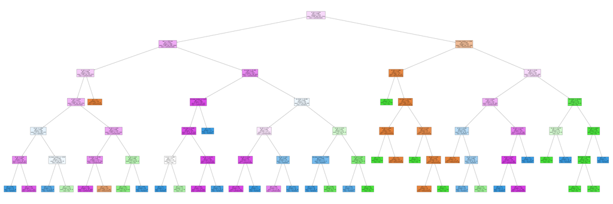

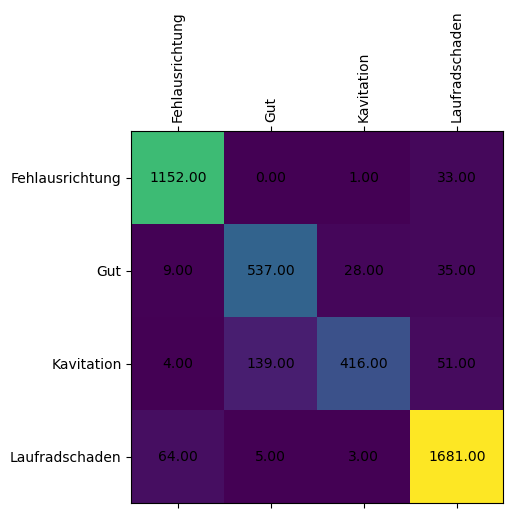

```
Test Accuracy: 0.911
Explained as: feature importances

Feature importances, computed as a decrease in score when feature
values are permuted (i.e. become noise). This is also known as
permutation importance.

If feature importances are computed on the same data as used for training,
they don't reflect importance of features for generalization. Use a held-out
dataset if you want generalization feature importances.

1.2969 ± 0.0343  s7_std
1.1877 ± 0.0569  rpm
1.1602 ± 0.0807  s2_range
0.5238 ± 0.0269  s3_mean_median
0.5146 ± 0.0257  s1_iqr
0.3822 ± 0.0158  s1_std
0.2559 ± 0.0212  s6_range
0.1861 ± 0.0124  s4_range
0.1579 ± 0.0063  s2_iqr
0.1058 ± 0.0031  s5_std
0.0550 ± 0.0027  s3_iqr
0.0360 ± 0.0087  s4_std
0.0336 ± 0.0024  s8_iqr
0.0189 ± 0.0010  s2_std
0.0141 ± 0.0030  s7_iqr
0.0137 ± 0.0016  s4_mean_median
0.0130 ± 0.0020  s8_range
0.0125 ± 0.0024  s4_iqr
0.0098 ± 0.0020  s6_mean_median
0.0093 ± 0.0007  s5_iqr
          … 14 more …
```

```python
# ANALYZE MODEL
import tensorflow as tf
from tensorflow import math as tfmath
import tensorflow_probability as tfp
import eli5
from eli5.sklearn import PermutationImportance
import joblib
from matplotlib import pyplot
from xgboost import XGBClassifier, plot_tree
from sklearn import tree
import matplotlib.pyplot as plt
from sklearn.metrics import accuracy_score

selectedTestFile = testFileDropdown.value
selectedModelFile = modelDropdown.value

print("Selected model: " + selectedModelFile)

csvTest = read_csv(PATH_FEATURE_DATA + selectedTestFile, delimiter=";")
testData = csvTest.values

testX, testY = testData[:,2:].astype(np.float32), testData[:, DATA_INDEX_CLASS:DATA_INDEX_CLASS+1]
featureNames = csvTest.columns.values[2:].tolist()

model = None
predictions = None
transformedTestY = None
confusionMatrix = None
classes = None
if (selectedModelFile.startswith('dnn')):
    onehotencoder = None
    with open(PATH_MODEL + selectedModelFile + '/encoder.pickle', 'rb') as f:
        onehotencoder = joblib.load(f)
    classes = onehotencoder.categories_[0]
    transformedTestY = onehotencoder.transform(testY).toarray()

    model = tf.keras.models.load_model(PATH_MODEL + selectedModelFile)
    predictions = model.predict(testX)

    confusionMatrix = tf.math.confusion_matrix(np.argmax(transformedTestY, axis=1), np.argmax(predictions, axis=1))
    equality = tf.math.equal(np.argmax(predictions, axis=1), np.argmax(transformedTestY, axis=1))
    accuracy = tf.math.reduce_mean(tf.cast(equality, tf.float32))
elif (selectedModelFile.startswith('xgb')):
    labelEncoder = None
    with open(PATH_MODEL + selectedModelFile + '/encoder.pickle', 'rb') as f:
        labelEncoder = joblib.load(f)
    classes = labelEncoder.classes_
    transformedTestY = labelEncoder.transform(np.ravel(testY))

    model = XGBClassifier()
    model.load_model(PATH_MODEL + selectedModelFile + '/xgb.model')
    predictions = model.predict(testX)
    confusionMatrix = tfmath.confusion_matrix(transformedTestY, predictions)

    for i in range(model.n_estimators):
        plot_tree(model, num_trees=i, fmap=PATH_MODEL + selectedModelFile + '/feature_map.txt')
        pyplot.gcf().set_dpi(1200)
        pyplot.show()


    #pyplot.show()
    equality = tf.math.equal(predictions, transformedTestY)
    accuracy = tf.math.reduce_mean(tf.cast(equality, tf.float32))
elif (selectedModelFile.startswith('dtc')):
    labelEncoder = None
    with open(PATH_MODEL + selectedModelFile + '/encoder.pickle', 'rb') as f:
        labelEncoder = joblib.load(f)
    classes = labelEncoder.classes_
    transformedTestY = labelEncoder.transform(np.ravel(testY))

    model = joblib.load(PATH_MODEL + selectedModelFile + '/dtc.model')

    predictions = model.predict(testX)
    accuracy = accuracy_score(transformedTestY, predictions)
    confusionMatrix = tfmath.confusion_matrix(transformedTestY, predictions)
    plt.figure(figsize=(120, 40))
    tree.plot_tree(model, feature_names=featureNames, class_names=labelEncoder.classes_, filled=True)
    plt.show()

mat = pyplot.matshow(confusionMatrix, 1)
mat.axes.set_xticks(np.arange(0, len(classes), 1))
mat.axes.set_yticks(np.arange(0, len(classes), 1))
mat.axes.set_xticklabels(classes, rotation=90)
mat.axes.set_yticklabels(classes)
for (x, y), value in np.ndenumerate(confusionMatrix):
    pyplot.text(y, x, f"{value:.2f}", va="center", ha="center")
pyplot.show()


print('Test Accuracy: %.3f' % accuracy)


#correlationMatrix = tfp.stats.correlation(testX)
#pyplot.matshow(correlationMatrix)
#pyplot.show()

perm = PermutationImportance(model, scoring="neg_mean_squared_error", random_state=1).fit(testX, transformedTestY)
print(eli5.format_as_text(eli5.explain_weights(perm, feature_names=featureNames)))
```

## 7. Statische Interpretation des Resultats

- Welches Ergebnis haben wir erzielt und wie kann man es anwenden?